# JUDGE channel — VII. The frame experiment

Similarity, difference, and rgb’s conditional — does JUDGE behave like a contrast model or like a conditional probability?

ecb

2026-07-28

## Design

Report VI read the JUDGE asymmetry as Tversky’s contrast model and got a good fit — half the directional variance is a single per-adjective prominence potential, the direction is right for 97% of high-gap pairs, and prominence separates cleanly from base rate and from lexical frequency. But two things were left standing.

1. **Everything was a statement about `(β − α)f`.** The focusing weights are not separately identified by data collected in one frame.
2. **The whole reading assumed `B[i,j]` is a similarity judgment.** rgb’s item is a *conditional* — “a person who is very *i*: how likely also *j*?” — and the deflationary rival is that it is simply `P(j | i)`, in which case Tversky is the wrong theory and the prominence scale is a base rate wearing a costume.

| frame | prompt | polarity |
| --- | --- | --- |
| `cond` | *Consider a person who is very **a**. How likely is this person to also be **b**?* | alikeness |
| `sim` | *How similar is a person who is very **a** to a person who is very **b**?* | alikeness |
| `diff` | *How different is a person who is very **a** from a person who is very **b**?* | differentness |

Same 1–7 instruction and same system message in all three, so a frame effect cannot come from the response format. The grammatical subject is Tversky’s *subject* role; running both orders is the focusing manipulation. Pairs are stratified 2 × 3 on **prominence gap** (top vs bottom decile of `|f_i − f_j|`, using the *f* recovered in Report VI §2 from all 273,006 archival cells) × **similarity tercile**, so that common-feature mass and distinctive-feature mass vary as independently as this item pool allows.

**What separates the two accounts.** With `c = f(A∩B)`, `u = f(A−B)`, `v = f(B−A)`: `s = θc − αu − βv` and `d = α'u + β'v − θ'c`, so `Δs = (β−α)(u−v)` and `Δd = (α'−β')(u−v)`. The raw sign therefore flips between frames — but so does any reverse-scored measure, so **the sign flip is not diagnostic** (Report VI §8.2 states this correction). The tests that do discriminate:

- **T1 non-complementarity (primary).** `s + d = (θ−θ')c + (α'−α)u + (β'−β)v`. If `diff` is just `sim` reverse-scored, the sum is **constant**. Under the contrast model it moves with the pair’s feature richness.
- **T2 asymmetry-to-signal ratio by frame.** Distinctive features weigh more in difference judgments, so the relative asymmetry should be larger in `diff`. Pure polarity reversal predicts equality.
- **T3 frame-invariance of *f*.** The archival prominence scale should predict the directional asymmetry in *both new frames* — genuine out-of-sample validation, which Report VI §2’s sign test explicitly was not.
- **T4 is `cond` a similarity judgment at all?** The assumption Report VI granted itself.

```r
tid <- read_csv_("frames_tidy.csv") %>% as_tibble()
FR  <- c("cond","sim","diff")
tid <- tid %>% mutate(frame = factor(frame, levels = FR))
MOD <- sort(unique(tid$model))
cat(sprintf("%d records | %d models | %d pairs | mean valid mass %.3f\n",
            nrow(tid), length(MOD), n_distinct(paste(tid$i, tid$j)), mean(tid$valid_mass, na.rm=TRUE)))
```

```
## 154 records | 1 models | 125 pairs | mean valid mass 1.000
```

## 1. Manipulation check

```r
tid %>% group_by(model, frame) %>%
  summarise(n = n(), mean = mean(ev), sd = sd(ev),
            `% at scale ends` = 100*mean(ev < 1.5 | ev > 6.5), .groups = "drop") %>%
  mutate(across(where(is.numeric), ~round(.,2))) %>%
  knitr::kable(caption = "Raw ratings by model and frame (EV over the 1-7 logprob distribution).")
```

Raw ratings by model and frame (EV over the 1-7 logprob distribution).

| model | frame | n | mean | sd | % at scale ends |
| --- | --- | --- | --- | --- | --- |
| gemma3-4b | cond | 38 | 3.76 | 1.51 | 13.16 |
| gemma3-4b | sim | 55 | 3.23 | 0.78 | 1.82 |
| gemma3-4b | diff | 61 | 6.06 | 0.98 | 44.26 |

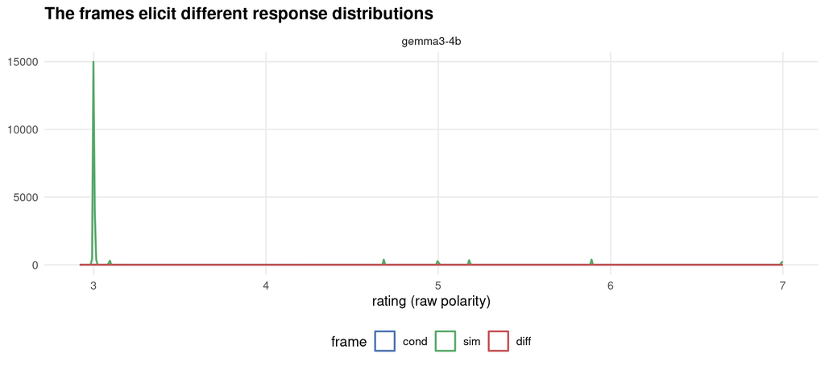

```r
ggplot(tid, aes(ev, colour = frame)) + geom_density(linewidth = 0.7) +
  facet_wrap(~model, nrow = 1) +
  scale_colour_manual(values = c(cond = "#4C72B0", sim = "#55A868", diff = "#C44E52")) +
  labs(title = "The frames elicit different response distributions",
       x = "rating (raw polarity)", y = NULL) + theme_judge()
```

## 2. T4 — is rgb’s conditional a similarity judgment?

Pair-level correspondence between the frames, averaging the two orders (so this is about the *symmetric* signal, not the asymmetry):

```r
wide <- tid %>% group_by(model, i, j, frame) %>% summarise(ev = mean(ev), .groups = "drop") %>%
  pivot_wider(names_from = frame, values_from = ev) %>%
  filter(!is.na(cond), !is.na(sim), !is.na(diff)) %>%   # complete pairs only
  mutate(diff_alike = 8 - diff)
arch <- {
  sym <- fread_gz("sym_ev.csv.gz"); disc <- setdiff(MODELS, c("Llama","FalconMamba"))
  S <- Reduce(`+`, lapply(disc, function(m) build_matrix(sym, m, "sym")))/length(disc)
  pr <- read_csv_("frame_pairs.csv") %>% as_tibble()
  pr %>% mutate(arch_sym = S[cbind(i+1L, j+1L)]) %>% select(i, j, arch_sym, gap, sym_design = sym,
                                                            f_i, f_j, block)
}
wide <- wide %>% left_join(arch, by = c("i","j"))
wide %>% group_by(model) %>%
  summarise(`cond ~ sim` = cor(cond, sim),
            `cond ~ reverse(diff)` = cor(cond, diff_alike),
            `sim ~ reverse(diff)`  = cor(sim, diff_alike),
            `cond ~ archival B` = cor(cond, arch_sym),
            `sim ~ archival B`  = cor(sim, arch_sym), .groups = "drop") %>%
  mutate(across(where(is.numeric), ~round(.,3))) %>%
  knitr::kable(caption = "Do the frames measure the same thing? (pair level, orders averaged). The archival column also validates this harness against rgb's original collection.")
```

Do the frames measure the same thing? (pair level, orders averaged). The archival column also validates this harness against rgb’s original collection.

| model | cond ~ sim | cond ~ reverse(diff) | sim ~ reverse(diff) | cond ~ archival B | sim ~ archival B |
| --- | --- | --- | --- | --- | --- |
| gemma3-4b | 0.286 | 0.973 | 0.501 | 0.969 | 0.513 |

## 3. T1 — non-complementarity (the primary test)

If `diff` is `sim` with the polarity reversed, `sim + diff` is a constant. Under the contrast model it varies with how much feature mass the pair has to work with.

```r
nc <- wide %>% mutate(sum_sd = sim + diff, rich = f_i + f_j)
nc %>% group_by(model) %>%
  summarise(`mean(sim+diff)` = mean(sum_sd), `SD(sim+diff)` = sd(sum_sd),
            `r with overlap (archival B)` = cor(sum_sd, arch_sym),
            `r with richness (f_i+f_j)` = cor(sum_sd, rich), .groups = "drop") %>%
  mutate(across(where(is.numeric), ~round(.,3))) %>%
  knitr::kable(caption = "T1: is sim + diff constant? A polarity-reversal account says SD ~ 0 and both correlations ~ 0.")
```

T1: is sim + diff constant? A polarity-reversal account says SD ~ 0 and both correlations ~ 0.

| model | mean(sim+diff) | SD(sim+diff) | r with overlap (archival B) | r with richness (f_i+f_j) |
| --- | --- | --- | --- | --- |
| gemma3-4b | 9.594 | 1.466 | -0.16 | -0.419 |

```r
map_dfr(MOD, function(m) {
  d <- nc %>% filter(model == m)
  if (nrow(d) < 10) return(tibble())
  fit <- lm(sum_sd ~ scale(arch_sym) + scale(rich), d)
  tibble(Model = m, n = nrow(d), `R²` = summary(fit)$r.squared,
         `b(overlap)` = coef(fit)[[2]], `t(overlap)` = summary(fit)$coefficients[2,3],
         `b(richness)` = coef(fit)[[3]], `t(richness)` = summary(fit)$coefficients[3,3])
}) %>% mutate(across(where(is.numeric), ~round(.,3))) %>%
  knitr::kable(caption = "T1 regression: sim + diff on standardized overlap and richness.")
```

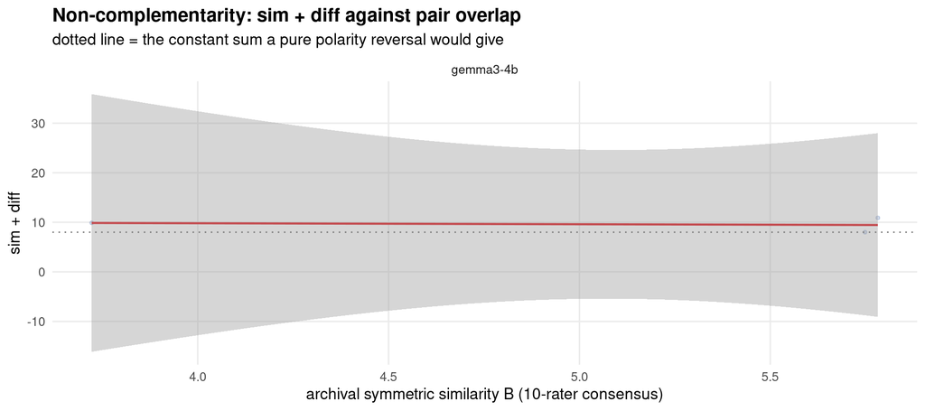

```r
ggplot(nc, aes(arch_sym, sum_sd)) +
  geom_point(alpha = 0.25, size = 0.9, colour = "#4C72B0") +
  geom_smooth(method = "lm", colour = "#C44E52", se = TRUE, linewidth = 0.7) +
  geom_hline(yintercept = 8, linetype = 3, colour = "grey50") +
  facet_wrap(~model, nrow = 1) +
  labs(title = "Non-complementarity: sim + diff against pair overlap",
       subtitle = "dotted line = the constant sum a pure polarity reversal would give",
       x = "archival symmetric similarity B (10-rater consensus)", y = "sim + diff") +
  theme_judge()
```

## 4. T3 — does the archival prominence scale predict the new frames?

For each frame, the directional asymmetry on the alikeness polarity, `Δ = r(i→j) − r(j→i)`, regressed on the archival prominence difference `f_i − f_j`. Report VI predicts a **negative** slope in every frame (the less prominent adjective is the better subject).

```r
asym <- tid %>%
  mutate(val = ev_alike) %>%
  select(model, i, j, frame, order, val) %>%
  pivot_wider(names_from = order, values_from = val) %>%
  filter(!is.na(ij), !is.na(ji)) %>%          # both orders needed for a delta
  mutate(delta = ij - ji) %>%
  left_join(arch, by = c("i","j")) %>%
  mutate(fdiff = f_i - f_j)

map_dfr(MOD, function(m) map_dfr(FR, function(f) {
  d <- asym %>% filter(model == m, frame == f)
  if (nrow(d) < 10) return(tibble())
  fit <- lm(delta ~ fdiff, d)
  tibble(Model = m, Frame = f, n = nrow(d), `slope on (f_i - f_j)` = coef(fit)[[2]],
         t = summary(fit)$coefficients[2,3], `r` = cor(d$delta, d$fdiff),
         `SD(Δ)` = sd(d$delta))
})) %>% mutate(across(where(is.numeric), ~round(.,3))) %>%
  knitr::kable(caption = "T3: out-of-sample validation of the Report VI prominence scale. Negative slope = predicted direction.")
```

## 5. T2 — asymmetry-to-signal ratio by frame

```r
sig <- tid %>% group_by(model, frame) %>% summarise(sd_rating = sd(ev), .groups = "drop")
asym %>% group_by(model, frame) %>% summarise(sd_delta = sd(delta), .groups = "drop") %>%
  left_join(sig, by = c("model","frame")) %>%
  mutate(ratio = sd_delta/sd_rating) %>%
  select(Model = model, Frame = frame, `SD(Δ)` = sd_delta, `SD(rating)` = sd_rating,
         `asymmetry ratio` = ratio) %>%
  mutate(across(where(is.numeric), ~round(.,3))) %>%
  knitr::kable(caption = "T2: relative asymmetry by frame. A polarity reversal predicts sim and diff to match.")
```

T2: relative asymmetry by frame. A polarity reversal predicts sim and diff to match.

| Model | Frame | SD(Δ) | SD(rating) | asymmetry ratio |
| --- | --- | --- | --- | --- |
| gemma3-4b | cond | 0.05 | 1.506 | 0.034 |
| gemma3-4b | sim | 0.00 | 0.781 | 0.000 |
| gemma3-4b | diff | NA | 0.980 | NA |

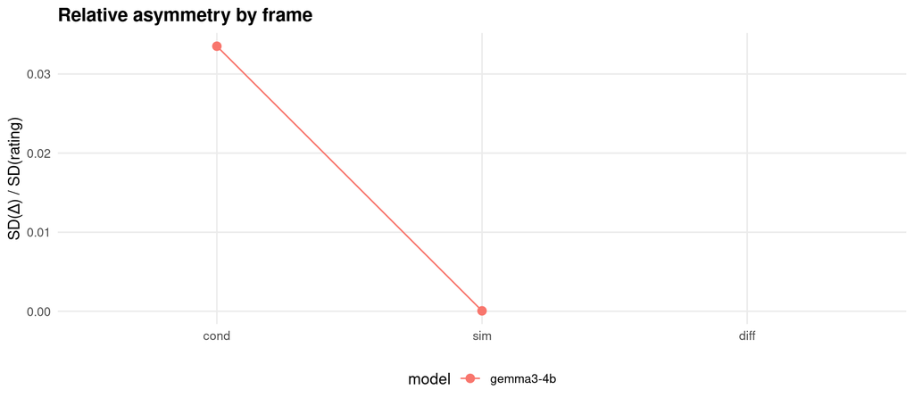

```r
asym %>% group_by(model, frame) %>% summarise(sd_delta = sd(delta), .groups="drop") %>%
  left_join(sig, by=c("model","frame")) %>% mutate(ratio = sd_delta/sd_rating) %>%
  ggplot(aes(frame, ratio, group = model, colour = model)) +
  geom_line() + geom_point(size = 2.5) +
  labs(title = "Relative asymmetry by frame", x = NULL,
       y = "SD(Δ) / SD(rating)") + theme_judge()
```

## 6. High-gap vs low-gap block

The design’s own manipulation check: the asymmetry should be concentrated in the high prominence-gap block, in every frame.

```r
asym %>% group_by(model, frame, block) %>%
  summarise(`mean |Δ|` = mean(abs(delta)), .groups = "drop") %>%
  pivot_wider(names_from = block, values_from = `mean |Δ|`) %>%
  mutate(ratio = high_gap/low_gap, across(where(is.numeric), ~round(.,3))) %>%
  knitr::kable(caption = "Mean |Δ| by prominence-gap block.")
```

Mean |Δ| by prominence-gap block.

| model | frame | high_gap | low_gap | ratio |
| --- | --- | --- | --- | --- |
| gemma3-4b | cond | 0 | 0.072 | 0.002 |
| gemma3-4b | sim | 0 | 0.000 | 128.127 |
| gemma3-4b | diff | NA | 0.000 | NA |